# Geog533 Lab 7 - Correlation

Michael Kezner

November 2, 2017

## Question 1

This is Exercise 1 in Chapter 7 of the Textbook [R].

### Problem 1a

Find the correlation coefficient, *r*, for the following sample data on income and education:

```r
library(knitr)
obs <- seq(1:5)
income1 <- c(30,28,52,40,35)
edu <- c(12,13,18,16,17)
df <- data.frame(obs,income1,edu)
names(df) <- c("Observation","Income ($*1000)","Education (Years)")
kable(df)
```

| Observation | Income ($*1000) | Education (Years) |
| --- | --- | --- |
| 1 | 30 | 12 |
| 2 | 28 | 13 |
| 3 | 52 | 18 |
| 4 | 40 | 16 |
| 5 | 35 | 17 |

### Solution 1a

```r
cor1a <- cor(income1, edu, method = "pearson")
round(cor1a, 3)
```

```
[1] 0.836
```

### Problem 1b

Test the null hypothesis ρ = 0.

### Solution 1b

```r
cor1b <- cor.test(income1, edu, method = "pearson")
cor1b
```

```
    Pearson's product-moment correlation

data:  income1 and edu
t = 2.6364, df = 3, p-value = 0.0779
alternative hypothesis: true correlation is not equal to 0
95 percent confidence interval:
 -0.1770427  0.9888709
sample estimates:
    cor
0.83577
```

```r
p1b <- cor1b$p.value
if(p1b < 0.05){
print("We reject the null hypothesis")
} else {
print("We fail to reject the null hypothesis")}
```

```
[1] "We fail to reject the null hypothesis"
```

### Problem 1c

Find Spearman’s rank correlation coefficient for these data.

### Solution 1c

```r
r1c <- cor(income1, edu, method = "spearman")
r1c
```

```
[1] 0.8
```

### Problem 1d

Test whether the observed value of rs from part (c) is significantly different from zero.

### Solution 1d

```r
test1d <- cor.test(income1, edu, method = "spearman")
test1d
```

```
    Spearman's rank correlation rho

data:  income1 and edu
S = 4, p-value = 0.1333
alternative hypothesis: true rho is not equal to 0
sample estimates:
rho
0.8
```

```r
p1d <- test1d$p.value
if(p1d < 0.05){
print("We reject the null hypothesis")
} else {
print("We fail to reject the null hypothesis")}
```

```
[1] "We fail to reject the null hypothesis"
```

## Question 2

This is Exercise 3 in Chapter 7 of the Textbook [R].

### Problem

The distribution of the t-statistic for testing the significance of a correlation coefficient has n – 2 degrees of freedom. If the sample size is 36 and α = 0.05, what is the smallest absolute value a correlation coefficient must have to be significant? What if the sample size is 80?

### Solution

#### Sample Size of 36

```r
df2a <- 36-2
crit2a <- qt(.975, df2a)
rcrit2a <- crit2a/sqrt(df2a+crit2a^2)
round(rcrit2a, 3)
```

```
[1] 0.329
```

#### Sample size of 80

```r
df2b <- 80-2
crit2b <- qt(.975, df2b)
rcrit2b <- crit2b/sqrt(df2b+crit2b^2)
round(rcrit2b, 3)
```

```
[1] 0.22
```

## Question 3

This is Exercise 4 in Chapter 7 of the Textbook [R].

### Problem

Find the correlation coefficient for the following data:

```r
library(knitr)
Obs <- seq(1:4)
X <- c(2,8,9,7)
Y <- c(6,6,10,4)
df <- data.frame(Obs,X,Y)
kable(df)
```

| Obs | X | Y |
| --- | --- | --- |
| 1 | 2 | 6 |
| 2 | 8 | 6 |
| 3 | 9 | 10 |
| 4 | 7 | 4 |

### Solution

```r
r3 <- cor(X,Y,method = "pearson")
round(r3, 3)
```

```
[1] 0.383
```

## Question 4

This is Exercise 6 in Chapter 7 of the Textbook [R].

### Problem

Find the correlation coefficient between median annual income in the United States and the number of horse races won by the leading jockey, for the period 1984–1995. Test the hypothesis that the true correlation coefficient is equal to zero. Interpret your results.

```r
year <- 1984:1994
income2 <- c(35165,35778,37027,37256,37512,37997,37343,36054,35593,35241,35486)
races <- c(399,469,429,450,474,598,364,430,433,410,317)
df <- data.frame(year,income2,races)
names(df) <- c("Year","Median income","Number of races won by leading jockey")
kable(df)
```

| Year | Median income | Number of races won by leading jockey |
| --- | --- | --- |
| 1984 | 35165 | 399 |
| 1985 | 35778 | 469 |
| 1986 | 37027 | 429 |
| 1987 | 37256 | 450 |
| 1988 | 37512 | 474 |
| 1989 | 37997 | 598 |
| 1990 | 37343 | 364 |
| 1991 | 36054 | 430 |
| 1992 | 35593 | 433 |
| 1993 | 35241 | 410 |
| 1994 | 35486 | 317 |

### Solution

```r
cor4 <- cor.test(income2, races, method = "pearson")
cor4
```

```
    Pearson's product-moment correlation

data:  income2 and races
t = 2.0189, df = 9, p-value = 0.07425
alternative hypothesis: true correlation is not equal to 0
95 percent confidence interval:
 -0.06248153  0.86761233
sample estimates:
      cor
0.5583199
```

```r
round(cor4$estimate,3)
```

```
  cor
0.558
```

```r
p4 <- cor4$p.value
if(p4 < 0.05){
print("We reject the null hypothesis")
} else {
print("We fail to reject the null hypothesis")}
```

```
[1] "We fail to reject the null hypothesis"
```

## Question 5

This is Exercise 7 in Chapter 7 of the Textbook [R].

### Problem

For the following ranked data, find Spearman’s r, and then test the null hypothesis (using a Type I error probability of 0.10) that the true correlation is equal to zero.

```r
library(knitr)
obs <- 1:6
x <- c(1,2,5,6,11,12)
y <- c(8,4,12,3,10,7)
df <- data.frame(obs,x,y)
names(df) <- c("Observation","Rank of x","Rank of y")
kable(df)
```

| Observation | Rank of x | Rank of y |
| --- | --- | --- |
| 1 | 1 | 8 |
| 2 | 2 | 4 |
| 3 | 5 | 12 |
| 4 | 6 | 3 |
| 5 | 11 | 10 |
| 6 | 12 | 7 |

### Solution

```r
test5 <- cor.test(x,y,method = "spearman")
test5
```

```
    Spearman's rank correlation rho

data:  x and y
S = 36, p-value = 1
alternative hypothesis: true rho is not equal to 0
sample estimates:
        rho
-0.02857143
```

```r
round(test5$estimate,3)
```

```
   rho
-0.029
```

```r
p5 <- 1
if(p5 < .10){
print("We reject the null hypothesis")
} else {
print("We fail to reject the null hypothesis")}
```

```
[1] "We fail to reject the null hypothesis"
```

## Question 6

This is Exercise 8 in Chapter 7 of the Textbook [R].

### Problem

Find Pearson’s r for the following data, and then test the null hypothesis that the correlation coefficient is equal to zero. Use a Type I error probability of 0.05.

```r
library(knitr)
obs <- 1:6
x6 <- c(3.2,2.4,1.6,8.3,7.2,5.1)
y6 <- c(6.2,7.3,8.1,2.6,6.3,4.3)
df <- data.frame(obs,x6,y6)
names(df) <- c("Observation","x","y")
kable(df)
```

| Observation | x | y |
| --- | --- | --- |
| 1 | 3.2 | 6.2 |
| 2 | 2.4 | 7.3 |
| 3 | 1.6 | 8.1 |
| 4 | 8.3 | 2.6 |
| 5 | 7.2 | 6.3 |
| 6 | 5.1 | 4.3 |

### Solution

```r
test6 <- cor.test(x6,y6,method = "pearson")
test6
```

```
    Pearson's product-moment correlation

data:  x6 and y6
t = -2.7364, df = 4, p-value = 0.0521
alternative hypothesis: true correlation is not equal to 0
95 percent confidence interval:
 -0.97806755  0.01221668
sample estimates:
       cor
-0.8073491
```

```r
round(test6$estimate, 3)
```

```
   cor
-0.807
```

```r
p6 <- test6$p.value
if(p6 < 0.05){
print("We reject the null hypothesis")
} else {
print("We fail to reject the null hypothesis")}
```

```
[1] "We fail to reject the null hypothesis"
```

## Question 7

This is Exercise 9 in Chapter 7 of the Textbook [R].

### Problem

Using R and the Milwaukee dataset, find the correlation between number of bedrooms and lot size.

### Solution

```r
mil <- read.csv("Milwaukee.csv")
cor7 <- cor(mil$Bedrms,mil$LotSize, method = "pearson")
round(cor7, 3)
```

```
[1] -0.005
```

## Question 8

This is Exercise 10 in Chapter 7 of the Textbook [R].

### Problem

Using R and the Hypothetical UK Housing Prices dataset, find the correlation between floor area and number of bedrooms.

### Solution

```r
housing <- read.csv("UK_Housing.csv")
cor8 <- cor(housing$floorarea,housing$bedrooms, method = "pearson")
round(cor8, 3)
```

```
[1] 0.611
```

## Problem 9

Use the **cars** data frame in the **datasets** package to perform the following tasks:

### Problem 9a

Plot a scatterplot for the data frame (x: speed, y: dist)

### Solution 9a

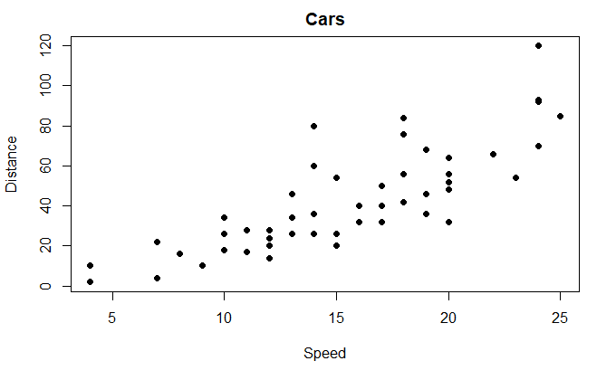

```r
library(datasets)
frame <- cars
xs <- frame$speed
yd <- frame$dist
plot(xs, yd, main = "Cars", xlab = "Speed", ylab = "Distance", pch = 16)
```

### Problem 9b

How many rows in the data frame?

### Solution 9b

```r
nrow(frame)
```

```
[1] 50
```

### Problem 9c

Calculate Pearson’s correlation coefficient using the equation below:
$$r=\frac{\sum_{n}^{i=1}(x_i-\bar{x})(y_i-\bar{y})}{(n-1)s_{x}s_{y}}$$

### Solution 9c

```r
xmean <- mean(xs)
ymean <- mean(yd)
x9c <- xs - xmean
y9c <- yd - ymean
sum9c <- sum(x9c*y9c)
s9x <- sd(xs)
s9y <- sd(yd)
r9c <- sum9c/(49*s9x*s9y)
r9c
```

```
[1] 0.8068949
```

```r
round(r9c,3)
```

```
[1] 0.807
```

### Problem 9d

Use the cor.test() function to find Pearson’s correlation coefficient and compare it to the one from part (c)

### Solution 9d

```r
test9d <- cor.test(xs, yd, method = "pearson")
test9d
```

```
    Pearson's product-moment correlation

data:  xs and yd
t = 9.464, df = 48, p-value = 1.49e-12
alternative hypothesis: true correlation is not equal to 0
95 percent confidence interval:
 0.6816422 0.8862036
sample estimates:
      cor
0.8068949
```

```r
round(test9d$estimate,3)
```

```
  cor
0.807
```

The correlation coefficient from using the equation in 9c is **the same as** the correlation coefficient found by running the cor.test() function

### Problem 9e

Calculate Spearman’s rank correlation coefficient using the equation below:
$$r_{S} = 1 - \frac{6\sum_{i=1}^{n}d_{i}^{2}}{n^3-n}$$

### Solution 9e

```r
frame$rankspeed <- rank(xs)
frame$rankdistance <- rank(yd)
frame$d <- frame$rankspeed - frame$rankdistance
num9 <- 6*sum(frame$d^2)
den9 <- (50^3)-50
r9e <- 1-(num9/den9)
round(r9e, 3)
```

```
[1] 0.831
```

### Problem 9f

Use the cor.test() function to find Spearman’s rank correlation coefficient and compare it to the one from part (e)

### Solution 9f

```r
test9f <- cor.test(xs,yd, method = "spearman")
test9f
```

```
    Spearman's rank correlation rho

data:  xs and yd
S = 3532.8, p-value = 8.825e-14
alternative hypothesis: true rho is not equal to 0
sample estimates:
      rho
0.8303568
```

```r
round(test9f$estimate,3)
```

```
 rho
0.83
```

The correlation coefficient obtained from using the equation in 9e is **0.001 greater than** the correlation coefficient obtained using the cor.test() function